# 92 · Method comparison

Every set test in the repository, on the same sets, the same contrasts and the same control

Four branches have run pathway tests on this dataset, with different tests, different set filters and different FDR families. Read one at a time, their counts cannot be compared: a set significant in one and not another may differ in the test, in the set list, or only in how many other sets shared its correction. This notebook puts all of them in one long table with the same column names, and then compares them where the comparison is fair.

It runs no test of its own. It reads the results of `90_Set_Test_Calibration` and `91_Sample_Scores_ssGSEA` from this branch, and snapshots of the other branches’ results taken by `a_script/92_snapshot_external.R`, each pinned to a commit in `c_data/external/external_manifest.csv`.

```r
library(here)
library(dplyr)
library(tidyr)
library(purrr)
library(readr)
library(ggplot2)
here::i_am("03_Pathway_Enrichment/92_Method_Comparison/a_script/92_method_comparison.qmd")

stage <- here("03_Pathway_Enrichment", "92_Method_Comparison")
out <- file.path(stage, "c_data")
ext <- file.path(out, "external")
design <- readRDS(here("02_Differential_Expression", "01_Design", "c_data", "design.rds"))
control <- design$negative_control

manifest <- read_csv(file.path(ext, "external_manifest.csv"), show_col_types = FALSE)
manifest |> select(source, owner, pull_request, commit, path, rows)
```

| source | owner | pull_request | commit | path | rows |
| --- | --- | --- | --- | --- | --- |
| dustyn_pr11_fgsea | Dustyn | 11 | b16fc4f | 03_Pathway_Enrichment/01_Gene_Sets/c_data/fgsea_results.csv | 10030 |
| dustyn_pr11_fry | Dustyn | 11 | b16fc4f | 03_Pathway_Enrichment/02_Set_Tests/c_data/fry_results.csv | 5160 |
| dustyn_pr15_fgsea | Dustyn | 15 | aa66aa0 | 03_Pathway_Enrichment/01_run_fgsea/c_data/fgsea_results.csv | 13660 |
| matheus_pr13 | Matheus | 13 | 62a2404 | 03_Pathway_Enrichment/02_Set_Tests/c_data/geneset_tests_long.csv | 18508 |

## One table, one set of names

Every row is one set, one contrast, one method, from one source. The columns mean the same thing everywhere:

| Column | Meaning |
| --- | --- |
| `source` | who ran it and where: `diego_90`, `diego_91`, or a snapshot name from the manifest |
| `method` | `fry`, `camera`, `fgsea`, or `ssGSEA_limma` (ssGSEA scores tested with limma) |
| `set_id` | `Database\|SET_NAME`, the MSigDB name, identical across sources |
| `n` | measured members the test used |
| `direction` | `Up` or `Down` |
| `effect` | fgsea NES, or the ssGSEA score difference; empty for fry and camera, which return none |
| `p` | the raw p-value, exactly as the source reported it |
| `padj_reported` | the adjusted p-value exactly as the source reported it |
| `fdr_family` | what that `padj_reported` was corrected across |

```r
ours_sets <- read_csv(here("03_Pathway_Enrichment", "90_Set_Test_Calibration", "c_data",
                           "set_test_results.csv"), show_col_types = FALSE) |>
  transmute(source = "diego_90", method, contrast, set_id, n, direction,
            effect = NES, p, padj_reported = padj,
            fdr_family = "method x contrast x database")

ours_scores <- read_csv(here("03_Pathway_Enrichment", "91_Sample_Scores_ssGSEA", "c_data",
                             "score_contrast_results.csv"), show_col_types = FALSE) |>
  transmute(source = "diego_91", method = "ssGSEA_limma", contrast, set_id, n = NA_real_,
            direction = if_else(diff > 0, "Up", "Down"), effect = diff, p,
            padj_reported = padj, fdr_family = "contrast x database")

read_ext <- function(name) read_csv(file.path(ext, paste0(name, ".csv.gz")),
                                    show_col_types = FALSE, guess_max = 1e5)

# PR 11 ran fgsea twice: once per database, and once on all three pooled after a cross-database
# overlap reduction. They are kept as two sources because their FDR families differ.
dustyn_pr11_fgsea <- read_ext("dustyn_pr11_fgsea") |>
  transmute(source = if_else(collection == "combined", "dustyn_pr11_fgsea_pooled",
                             "dustyn_pr11_fgsea"),
            method = "fgsea", contrast, set_id = pathway,
            n = size, direction = if_else(NES > 0, "Up", "Down"), effect = NES, p = pval,
            padj_reported = padj,
            fdr_family = if_else(collection == "combined", "contrast (all databases pooled)",
                                 "contrast x database"))

dustyn_pr11_fry <- read_ext("dustyn_pr11_fry") |>
  transmute(source = "dustyn_pr11_fry", method = "fry", contrast, set_id, n = NGenes,
            direction = Direction, effect = NA_real_, p = PValue, padj_reported = FDR,
            fdr_family = "contrast (all databases pooled)")

dustyn_pr15_fgsea <- read_ext("dustyn_pr15_fgsea") |>
  transmute(source = "dustyn_pr15_fgsea", method = "fgsea", contrast, set_id, n = size,
            direction = if_else(NES > 0, "Up", "Down"), effect = NES, p = pval,
            padj_reported = padj, fdr_family = "contrast (all databases pooled)")

matheus_db <- c("GO:BP" = "GOBP", "Hallmark" = "Hallmark", "Reactome" = "Reactome",
                "KEGG" = "KEGG_Legacy")
matheus <- read_ext("matheus_pr13") |>
  mutate(set_id = paste(matheus_db[collection], gs_name, sep = "|"))
matheus_pr13 <- bind_rows(
  transmute(matheus, method = "camera", contrast, set_id, n = n_matched,
            direction = camera_dir, p = camera_p, padj_reported = camera_fdr),
  transmute(matheus, method = "fry", contrast, set_id, n = n_matched,
            direction = fry_dir, p = fry_p, padj_reported = fry_fdr)
) |>
  mutate(source = "matheus_pr13", effect = NA_real_,
         fdr_family = "method x contrast x database", .before = 1)

comparison <- bind_rows(ours_sets, ours_scores, dustyn_pr11_fgsea, dustyn_pr11_fry,
                        dustyn_pr15_fgsea, matheus_pr13) |>
  separate_wider_delim(set_id, "|", names = c("database", "pathway"), cols_remove = FALSE) |>
  mutate(test = paste(source, method, sep = ":")) |>
  relocate(test, source, method, contrast, set_id, database, pathway)

stopifnot(!anyNA(comparison$p), all(comparison$direction %in% c("Up", "Down")),
          !anyDuplicated(select(comparison, test, contrast, set_id)))
comparison |>
  summarise(sets = n_distinct(set_id), contrasts = n_distinct(contrast),
            databases = paste(sort(unique(database)), collapse = ", "), .by = test)
```

| test | sets | contrasts | databases |
| --- | --- | --- | --- |
| diego_90:fry | 1040 | 5 | GOBP, Hallmark, Reactome |
| diego_90:camera | 1040 | 5 | GOBP, Hallmark, Reactome |
| diego_90:fgsea | 1040 | 5 | GOBP, Hallmark, Reactome |
| diego_91:ssGSEA_limma | 1040 | 5 | GOBP, Hallmark, Reactome |
| dustyn_pr11_fgsea:fgsea | 1007 | 5 | GOBP, Hallmark, Reactome |
| dustyn_pr11_fgsea_pooled:fgsea | 999 | 5 | GOBP, Hallmark, Reactome |
| dustyn_pr11_fry:fry | 1032 | 5 | GOBP, Hallmark, Reactome |
| dustyn_pr15_fgsea:fgsea | 2732 | 5 | BioCarta, GOBP, GOCC, GOMF, Hallmark, KEGG_Legacy, KEGG_Medicus, PID, Reactome, WikiPathways |
| matheus_pr13:camera | 4627 | 4 | GOBP, Hallmark, KEGG_Legacy, Reactome |
| matheus_pr13:fry | 4627 | 4 | GOBP, Hallmark, KEGG_Legacy, Reactome |

The set lists differ by design, not by accident: the floor on measured members is 10 in `diego_*` and `dustyn_pr11_*`, 15 with a ceiling of 500 in `dustyn_pr15_fgsea`, and 5 in `matheus_pr13`; each branch also removes near-duplicate sets its own way. `matheus_pr13` does not test `BFR_vs_HLRT_at_T2`.

## A fair comparison needs the same sets and the same FDR family

Two corrections are made before anything is counted.

- **Same sets.** Only sets that every test ran on, in that contrast, are compared.
- **Same FDR family.** `padj_reported` is corrected across different numbers of sets in different sources, so it is recomputed as `padj_common`: BH within one test, one contrast and one database, over the shared sets only. This is the only adjusted value used below.

The raw p-value needs neither correction, so it is compared directly.

The pooled fgsea run from PR 11 stays in `comparison_long.csv` but is left out from here on: its cross-database overlap reduction drops sets the per-database run keeps, and the per-database run is the same test on the same ranking.

```r
shared_scope <- filter(comparison, source != "dustyn_pr11_fgsea_pooled")
tests_per_contrast <- shared_scope |> distinct(contrast, test) |> count(contrast, name = "tests")
common <- shared_scope |>
  distinct(contrast, set_id, test) |>
  count(contrast, set_id, name = "tests_with_set") |>
  inner_join(tests_per_contrast, by = "contrast") |>
  filter(tests_with_set == tests) |>
  select(contrast, set_id)

comparison_common <- shared_scope |>
  semi_join(common, by = c("contrast", "set_id")) |>
  mutate(padj_common = p.adjust(p, "BH"), .by = c(test, contrast, database))

common |>
  separate_wider_delim(set_id, "|", names = c("database", "pathway")) |>
  count(contrast, database, name = "shared_sets") |>
  pivot_wider(names_from = database, values_from = shared_sets, values_fill = 0L)
```

| contrast | GOBP | Hallmark | Reactome |
| --- | --- | --- | --- |
| BFR_post_vs_pre | 760 | 41 | 195 |
| BFR_vs_HLRT_at_T1 | 760 | 41 | 195 |
| BFR_vs_HLRT_at_T2 | 760 | 41 | 195 |
| HLRT_post_vs_pre | 760 | 41 | 195 |
| interaction | 760 | 41 | 195 |

## The negative control, for every test

BFR_vs_HLRT_at_T1 compares two untrained legs of the same person, so every call here is a false positive. Under a calibrated test the p-values are uniform: median near 0.5 and about 5% below 0.05. This is the table to read before any other, because it says which tests can be believed on the interaction.

```r
control_calibration <- bind_rows(
  comparison |>
    filter(contrast == control) |>
    summarise(sets = n(), sig_reported = sum(padj_reported < params$fdr),
              median_p = round(median(p), 3), p_below_05 = round(mean(p < 0.05), 3),
              .by = c(test, source, method)) |>
    mutate(scope = "all sets the source tested"),
  comparison_common |>
    filter(contrast == control) |>
    summarise(sets = n(), sig_common = sum(padj_common < params$fdr),
              median_p = round(median(p), 3), p_below_05 = round(mean(p < 0.05), 3),
              .by = c(test, source, method)) |>
    mutate(scope = "shared sets only")
) |>
  relocate(scope, .after = method) |>
  arrange(scope, method, source)
control_calibration
```

| test | source | method | scope | sets | sig_reported | median_p | p_below_05 | sig_common |
| --- | --- | --- | --- | --- | --- | --- | --- | --- |
| diego_90:camera | diego_90 | camera | all sets the source tested | 1040 | 1 | 0.539 | 0.043 | NA |
| matheus_pr13:camera | matheus_pr13 | camera | all sets the source tested | 4627 | 2 | 0.518 | 0.038 | NA |
| diego_90:fgsea | diego_90 | fgsea | all sets the source tested | 1040 | 3 | 0.517 | 0.059 | NA |
| dustyn_pr11_fgsea:fgsea | dustyn_pr11_fgsea | fgsea | all sets the source tested | 1007 | 3 | 0.508 | 0.060 | NA |
| dustyn_pr11_fgsea_pooled:fgsea | dustyn_pr11_fgsea_pooled | fgsea | all sets the source tested | 999 | 1 | 0.507 | 0.057 | NA |
| dustyn_pr15_fgsea:fgsea | dustyn_pr15_fgsea | fgsea | all sets the source tested | 2732 | 14 | 0.501 | 0.068 | NA |
| diego_90:fry | diego_90 | fry | all sets the source tested | 1040 | 0 | 0.583 | 0.016 | NA |
| dustyn_pr11_fry:fry | dustyn_pr11_fry | fry | all sets the source tested | 1032 | 0 | 0.582 | 0.016 | NA |
| matheus_pr13:fry | matheus_pr13 | fry | all sets the source tested | 4627 | 0 | 0.563 | 0.019 | NA |
| diego_91:ssGSEA_limma | diego_91 | ssGSEA_limma | all sets the source tested | 1040 | 0 | 0.510 | 0.032 | NA |
| diego_90:camera | diego_90 | camera | shared sets only | 996 | NA | 0.536 | 0.042 | 1 |
| matheus_pr13:camera | matheus_pr13 | camera | shared sets only | 996 | NA | 0.536 | 0.043 | 1 |
| diego_90:fgsea | diego_90 | fgsea | shared sets only | 996 | NA | 0.512 | 0.058 | 3 |
| dustyn_pr11_fgsea:fgsea | dustyn_pr11_fgsea | fgsea | shared sets only | 996 | NA | 0.507 | 0.059 | 3 |
| dustyn_pr15_fgsea:fgsea | dustyn_pr15_fgsea | fgsea | shared sets only | 996 | NA | 0.506 | 0.059 | 3 |
| diego_90:fry | diego_90 | fry | shared sets only | 996 | NA | 0.580 | 0.016 | 0 |
| dustyn_pr11_fry:fry | dustyn_pr11_fry | fry | shared sets only | 996 | NA | 0.580 | 0.016 | 0 |
| matheus_pr13:fry | matheus_pr13 | fry | shared sets only | 996 | NA | 0.579 | 0.017 | 0 |
| diego_91:ssGSEA_limma | diego_91 | ssGSEA_limma | shared sets only | 996 | NA | 0.507 | 0.030 | 0 |

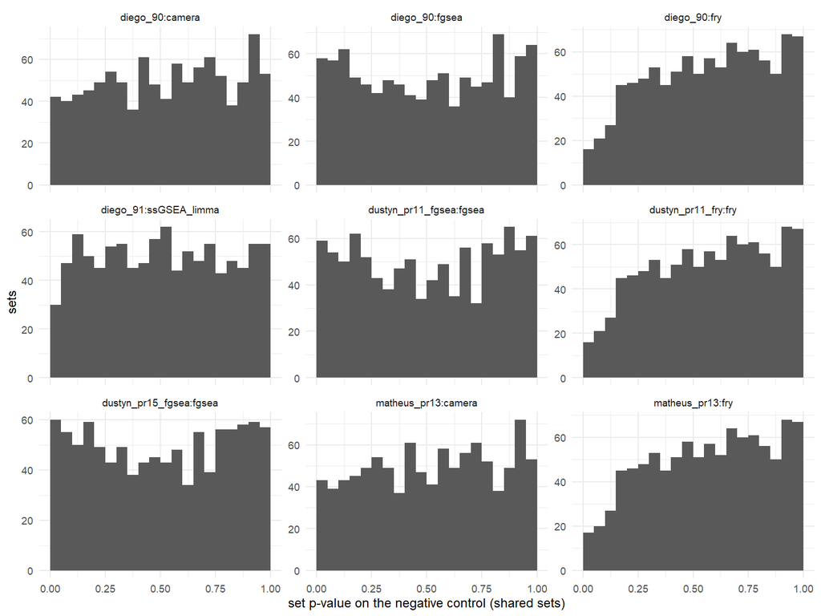

```r
comparison_common |>
  filter(contrast == control) |>
  ggplot(aes(p)) +
  geom_histogram(binwidth = 0.05, boundary = 0, fill = "grey35") +
  facet_wrap(~test, scales = "free_y", ncol = 3) +
  labs(x = "set p-value on the negative control (shared sets)", y = "sets") +
  theme_minimal(base_size = 9)
```

```r
comparison_common |>
  filter(contrast == control, padj_common < params$fdr) |>
  arrange(padj_common) |>
  transmute(test, set_id, n, direction, effect = round(effect, 2),
            padj_common = signif(padj_common, 3))
```

| test | set_id | n | direction | effect | padj_common |
| --- | --- | --- | --- | --- | --- |
| diego_90:camera | Reactome\|REACTOME_STRIATED_MUSCLE_CONTRACTION | 30 | Down | NA | 2.10e-06 |
| matheus_pr13:camera | Reactome\|REACTOME_STRIATED_MUSCLE_CONTRACTION | 30 | Down | NA | 2.10e-06 |
| dustyn_pr11_fgsea:fgsea | Reactome\|REACTOME_STRIATED_MUSCLE_CONTRACTION | 30 | Down | -2.52 | 6.70e-06 |
| diego_90:fgsea | Reactome\|REACTOME_STRIATED_MUSCLE_CONTRACTION | 30 | Down | -2.52 | 1.16e-05 |
| dustyn_pr15_fgsea:fgsea | Reactome\|REACTOME_STRIATED_MUSCLE_CONTRACTION | 30 | Down | -2.51 | 1.16e-05 |
| diego_90:fgsea | Reactome\|REACTOME_MUSCLE_CONTRACTION | 86 | Down | -1.81 | 1.28e-02 |
| dustyn_pr11_fgsea:fgsea | Hallmark\|HALLMARK_HEME_METABOLISM | 65 | Down | -1.78 | 2.51e-02 |
| dustyn_pr15_fgsea:fgsea | Hallmark\|HALLMARK_HEME_METABOLISM | 65 | Down | -1.82 | 2.83e-02 |
| diego_90:fgsea | Hallmark\|HALLMARK_HEME_METABOLISM | 65 | Down | -1.84 | 2.91e-02 |
| dustyn_pr11_fgsea:fgsea | Reactome\|REACTOME_MUSCLE_CONTRACTION | 86 | Down | -1.79 | 3.10e-02 |
| dustyn_pr15_fgsea:fgsea | Reactome\|REACTOME_MUSCLE_CONTRACTION | 86 | Down | -1.79 | 4.33e-02 |

## Do the same tests agree across branches

The same function on the same set should return the same p-value. Where it does not, the difference is in the inputs: which proteins mapped to the set, which weights were used, or which fit. This is a reproducibility check, not a finding.

```r
pair_up <- function(a, b) {
  inner_join(filter(comparison, test == a), filter(comparison, test == b),
             by = c("contrast", "set_id"), suffix = c("_a", "_b")) |>
    summarise(
      pair = paste(a, "vs", b), shared = n(),
      same_n = round(mean(n_a == n_b, na.rm = TRUE), 3),
      same_direction = round(mean(direction_a == direction_b), 3),
      spearman_log_p = round(cor(-log10(p_a), -log10(p_b), method = "spearman"), 3),
      max_abs_diff_log10_p = signif(max(abs(log10(p_a) - log10(p_b))), 3)
    )
}
same_method <- bind_rows(
  pair_up("diego_90:fry", "dustyn_pr11_fry:fry"),
  pair_up("diego_90:fry", "matheus_pr13:fry"),
  pair_up("diego_90:camera", "matheus_pr13:camera"),
  pair_up("diego_90:fgsea", "dustyn_pr11_fgsea:fgsea"),
  pair_up("diego_90:fgsea", "dustyn_pr15_fgsea:fgsea")
)
same_method
```

| pair | shared | same_n | same_direction | spearman_log_p | max_abs_diff_log10_p |
| --- | --- | --- | --- | --- | --- |
| diego_90:fry vs dustyn_pr11_fry:fry | 5140 | 1.000 | 1 | 1.000 | 0.000 |
| diego_90:fry vs matheus_pr13:fry | 4160 | 0.998 | 1 | 1.000 | 0.351 |
| diego_90:camera vs matheus_pr13:camera | 4160 | 0.998 | 1 | 1.000 | 0.296 |
| diego_90:fgsea vs dustyn_pr11_fgsea:fgsea | 5035 | 1.000 | 1 | 0.998 | 0.928 |
| diego_90:fgsea vs dustyn_pr15_fgsea:fgsea | 5200 | 1.000 | 1 | 0.997 | 1.210 |

`diego_90` and `dustyn_pr11_fry` both read the weights from `fit$EList$weights`. `matheus_pr13` refits with `dpcDE(sample.weights = TRUE)`, so its weights differ and its p-values should differ a little. fgsea’s p-values also move between runs and versions because it samples.

## How many sets each test calls, on shared sets

```r
call_counts <- comparison_common |>
  summarise(up = sum(padj_common < params$fdr & direction == "Up"),
            down = sum(padj_common < params$fdr & direction == "Down"),
            .by = c(contrast, database, test)) |>
  mutate(calls = paste0(up, " up / ", down, " down")) |>
  select(contrast, database, test, calls) |>
  pivot_wider(names_from = test, values_from = calls) |>
  arrange(match(contrast, c(control, setdiff(unique(contrast), control))), database)
call_counts
```

| contrast | database | diego_90:fry | diego_90:camera | diego_90:fgsea | diego_91:ssGSEA_limma | dustyn_pr11_fgsea:fgsea | dustyn_pr11_fry:fry | dustyn_pr15_fgsea:fgsea | matheus_pr13:camera | matheus_pr13:fry |
| --- | --- | --- | --- | --- | --- | --- | --- | --- | --- | --- |
| BFR_vs_HLRT_at_T1 | GOBP | 0 up / 0 down | 0 up / 0 down | 0 up / 0 down | 0 up / 0 down | 0 up / 0 down | 0 up / 0 down | 0 up / 0 down | 0 up / 0 down | 0 up / 0 down |
| BFR_vs_HLRT_at_T1 | Hallmark | 0 up / 0 down | 0 up / 0 down | 0 up / 1 down | 0 up / 0 down | 0 up / 1 down | 0 up / 0 down | 0 up / 1 down | 0 up / 0 down | 0 up / 0 down |
| BFR_vs_HLRT_at_T1 | Reactome | 0 up / 0 down | 0 up / 1 down | 0 up / 2 down | 0 up / 0 down | 0 up / 2 down | 0 up / 0 down | 0 up / 2 down | 0 up / 1 down | 0 up / 0 down |
| BFR_post_vs_pre | GOBP | 37 up / 161 down | 19 up / 24 down | 29 up / 46 down | 20 up / 35 down | 29 up / 44 down | 37 up / 161 down | 30 up / 45 down | 19 up / 24 down | 37 up / 161 down |
| BFR_post_vs_pre | Hallmark | 4 up / 4 down | 2 up / 1 down | 3 up / 2 down | 1 up / 0 down | 3 up / 1 down | 4 up / 4 down | 3 up / 2 down | 2 up / 1 down | 4 up / 4 down |
| BFR_post_vs_pre | Reactome | 16 up / 36 down | 14 up / 19 down | 15 up / 26 down | 7 up / 1 down | 15 up / 23 down | 16 up / 36 down | 15 up / 27 down | 14 up / 19 down | 16 up / 36 down |
| HLRT_post_vs_pre | GOBP | 44 up / 120 down | 11 up / 3 down | 14 up / 15 down | 5 up / 15 down | 14 up / 15 down | 44 up / 120 down | 13 up / 13 down | 11 up / 3 down | 44 up / 120 down |
| HLRT_post_vs_pre | Hallmark | 3 up / 2 down | 1 up / 0 down | 2 up / 1 down | 2 up / 1 down | 2 up / 0 down | 3 up / 2 down | 2 up / 1 down | 1 up / 0 down | 3 up / 2 down |
| HLRT_post_vs_pre | Reactome | 18 up / 36 down | 10 up / 6 down | 16 up / 21 down | 3 up / 2 down | 15 up / 18 down | 18 up / 36 down | 16 up / 22 down | 10 up / 6 down | 18 up / 36 down |
| BFR_vs_HLRT_at_T2 | GOBP | 0 up / 0 down | 11 up / 11 down | 18 up / 25 down | 0 up / 0 down | 18 up / 24 down | 0 up / 0 down | 19 up / 24 down | NA | NA |
| BFR_vs_HLRT_at_T2 | Hallmark | 0 up / 0 down | 2 up / 2 down | 2 up / 3 down | 0 up / 0 down | 2 up / 3 down | 0 up / 0 down | 2 up / 3 down | NA | NA |
| BFR_vs_HLRT_at_T2 | Reactome | 0 up / 0 down | 4 up / 4 down | 6 up / 8 down | 0 up / 0 down | 5 up / 6 down | 0 up / 0 down | 5 up / 8 down | NA | NA |
| interaction | GOBP | 0 up / 0 down | 0 up / 0 down | 2 up / 5 down | 0 up / 0 down | 2 up / 6 down | 0 up / 0 down | 1 up / 3 down | 0 up / 0 down | 0 up / 0 down |
| interaction | Hallmark | 0 up / 0 down | 0 up / 0 down | 1 up / 0 down | 0 up / 0 down | 1 up / 0 down | 0 up / 0 down | 1 up / 0 down | 0 up / 0 down | 0 up / 0 down |
| interaction | Reactome | 0 up / 0 down | 0 up / 0 down | 0 up / 0 down | 0 up / 0 down | 0 up / 0 down | 0 up / 0 down | 0 up / 0 down | 0 up / 0 down | 0 up / 0 down |

## Hallmark, side by side

One row per Hallmark set and contrast, one column per test, holding `padj_common` with the direction as a sign: `+0.003` is up at FDR 0.003, `-0.02` is down at FDR 0.02. Only rows where at least one test calls the set are shown; the CSV holds every row.

```r
hallmark_side_by_side <- comparison_common |>
  filter(database == "Hallmark") |>
  mutate(value = if_else(direction == "Up", 1, -1) * signif(padj_common, 2)) |>
  select(contrast, pathway, test, value) |>
  pivot_wider(names_from = test, values_from = value) |>
  mutate(pathway = sub("^HALLMARK_", "", pathway))

hallmark_side_by_side |>
  mutate(tests_calling = rowSums(abs(across(-c(contrast, pathway))) < params$fdr,
                                 na.rm = TRUE)) |>
  filter(tests_calling > 0) |>
  arrange(match(contrast, c(control, setdiff(unique(contrast), control))),
          desc(tests_calling)) |>
  group_split(contrast) |>
  walk(\(block) {
    knitr::kable(select(block, -contrast), caption = block$contrast[1], format = "pipe") |>
      cat(sep = "\n")
    cat("\n\n")
  })
```

BFR_post_vs_pre

| pathway | diego_90:fry | diego_90:camera | diego_90:fgsea | diego_91:ssGSEA_limma | dustyn_pr11_fgsea:fgsea | dustyn_pr11_fry:fry | dustyn_pr15_fgsea:fgsea | matheus_pr13:camera | matheus_pr13:fry | tests_calling |
| --- | --- | --- | --- | --- | --- | --- | --- | --- | --- | --- |
| OXIDATIVE_PHOSPHORYLATION | 0.00048 | 0.0000 | 0.0e+00 | 0.013 | 0.0e+00 | 0.00048 | 0.0e+00 | 0.0000 | 0.00048 | 9 |
| FATTY_ACID_METABOLISM | 0.01200 | 0.0079 | 1.2e-05 | 0.530 | 5.7e-06 | 0.01200 | 9.5e-06 | 0.0079 | 0.01200 | 8 |
| MYOGENESIS | -0.03600 | -0.0079 | -1.1e-04 | -0.390 | -1.5e-04 | -0.03600 | -2.0e-04 | -0.0079 | -0.03600 | 8 |
| ADIPOGENESIS | 0.02800 | 0.1100 | 1.7e-02 | 0.790 | 2.3e-02 | 0.02800 | 2.8e-02 | 0.1100 | 0.02800 | 6 |
| G2M_CHECKPOINT | -0.00430 | -0.1100 | -4.7e-02 | -0.300 | -5.0e-02 | -0.00430 | -3.5e-02 | -0.1100 | -0.00430 | 5 |
| KRAS_SIGNALING_DN | -0.00430 | -0.1500 | -8.0e-02 | -0.660 | -6.0e-02 | -0.00430 | -6.2e-02 | -0.1500 | -0.00430 | 3 |
| SPERMATOGENESIS | -0.02800 | -0.5400 | -2.6e-01 | -0.790 | -2.7e-01 | -0.02800 | -2.7e-01 | -0.5400 | -0.02800 | 3 |
| PEROXISOME | 0.02800 | 0.2400 | 2.6e-01 | 0.730 | 1.9e-01 | 0.02800 | 1.9e-01 | 0.2400 | 0.02800 | 3 |

BFR_vs_HLRT_at_T1

| pathway | diego_90:fry | diego_90:camera | diego_90:fgsea | diego_91:ssGSEA_limma | dustyn_pr11_fgsea:fgsea | dustyn_pr11_fry:fry | dustyn_pr15_fgsea:fgsea | matheus_pr13:camera | matheus_pr13:fry | tests_calling |
| --- | --- | --- | --- | --- | --- | --- | --- | --- | --- | --- |
| HEME_METABOLISM | -0.96 | -0.42 | -0.029 | -0.95 | -0.025 | -0.96 | -0.028 | -0.42 | -0.96 | 3 |

BFR_vs_HLRT_at_T2

| pathway | diego_90:fry | diego_90:camera | diego_90:fgsea | diego_91:ssGSEA_limma | dustyn_pr11_fgsea:fgsea | dustyn_pr11_fry:fry | dustyn_pr15_fgsea:fgsea | matheus_pr13:camera | matheus_pr13:fry | tests_calling |
| --- | --- | --- | --- | --- | --- | --- | --- | --- | --- | --- |
| BILE_ACID_METABOLISM | 0.11 | 0.017 | 0.01200 | 0.56 | 0.00920 | 0.11 | 0.00890 | NA | NA | 4 |
| MYOGENESIS | -0.58 | -0.016 | -0.00029 | -0.59 | -0.00045 | -0.58 | -0.00085 | NA | NA | 4 |
| FATTY_ACID_METABOLISM | 0.58 | 0.032 | 0.01800 | 0.62 | 0.01200 | 0.58 | 0.01100 | NA | NA | 4 |
| EPITHELIAL_MESENCHYMAL_TRANSITION | -0.64 | -0.017 | -0.00250 | -0.59 | -0.00390 | -0.64 | -0.00890 | NA | NA | 4 |
| APICAL_JUNCTION | -0.64 | -0.130 | -0.01600 | -0.59 | -0.01200 | -0.64 | -0.01500 | NA | NA | 3 |

HLRT_post_vs_pre

| pathway | diego_90:fry | diego_90:camera | diego_90:fgsea | diego_91:ssGSEA_limma | dustyn_pr11_fgsea:fgsea | dustyn_pr11_fry:fry | dustyn_pr15_fgsea:fgsea | matheus_pr13:camera | matheus_pr13:fry | tests_calling |
| --- | --- | --- | --- | --- | --- | --- | --- | --- | --- | --- |
| OXIDATIVE_PHOSPHORYLATION | 2.1e-05 | 0.000 | 0.000 | 0.013 | 0.000 | 2.1e-05 | 0.000 | 0.000 | 2.1e-05 | 9 |
| SPERMATOGENESIS | -1.3e-05 | -0.096 | -0.039 | -0.013 | -0.050 | -1.3e-05 | -0.046 | -0.096 | -1.3e-05 | 6 |
| APICAL_JUNCTION | 3.1e-02 | 0.073 | 0.018 | 0.280 | 0.018 | 3.1e-02 | 0.016 | 0.073 | 3.1e-02 | 6 |
| ALLOGRAFT_REJECTION | 4.7e-02 | 0.400 | 0.240 | 0.044 | 0.300 | 4.7e-02 | 0.290 | 0.400 | 4.7e-02 | 4 |
| G2M_CHECKPOINT | -1.1e-02 | -0.180 | -0.140 | -0.081 | -0.230 | -1.1e-02 | -0.210 | -0.180 | -1.1e-02 | 3 |

interaction

| pathway | diego_90:fry | diego_90:camera | diego_90:fgsea | diego_91:ssGSEA_limma | dustyn_pr11_fgsea:fgsea | dustyn_pr11_fry:fry | dustyn_pr15_fgsea:fgsea | matheus_pr13:camera | matheus_pr13:fry | tests_calling |
| --- | --- | --- | --- | --- | --- | --- | --- | --- | --- | --- |
| HEME_METABOLISM | 0.88 | 0.22 | 0.015 | 0.87 | 0.018 | 0.88 | 0.013 | 0.22 | 0.88 | 3 |

## Export

```r
# The long tables are compressed; readr, R and Excel's Power Query open .csv.gz directly.
write_csv(comparison, file.path(out, "comparison_long.csv.gz"))
write_csv(comparison_common, file.path(out, "comparison_shared_sets.csv.gz"))
write_csv(control_calibration, file.path(out, "control_calibration.csv"))
write_csv(same_method, file.path(out, "same_method_agreement.csv"))
write_csv(call_counts, file.path(out, "call_counts_shared_sets.csv"))
write_csv(hallmark_side_by_side, file.path(out, "hallmark_side_by_side.csv"))

# The same small tables as one workbook, for readers who check in Excel. The long tables stay
# in the .csv.gz files; a sheet cannot hold them comfortably.
writexl::write_xlsx(list(
  read_me = tibble::tibble(
    sheet = c("control_calibration", "same_method_agreement", "call_counts_shared_sets",
              "hallmark_side_by_side", "external_manifest"),
    what = c("negative control, every test: calls, median p, share of p < 0.05",
             "same function run in two branches: do n, direction and p agree",
             "sets called at FDR < 0.05 on the shared sets, BH recomputed per test, contrast, database",
             "Hallmark padj_common per test; sign is the direction",
             "which commit and file each snapshot came from")),
  control_calibration = control_calibration,
  same_method_agreement = same_method,
  call_counts_shared_sets = call_counts,
  hallmark_side_by_side = hallmark_side_by_side,
  external_manifest = manifest
), file.path(out, "92_method_comparison.xlsx"))
tibble(file = list.files(out), bytes = file.size(file.path(out, list.files(out))))
```

| file | bytes |
| --- | --- |
| 92_method_comparison.xlsx | 20328 |
| call_counts_shared_sets.csv | 2448 |
| comparison_long.csv.gz | 3052407 |
| comparison_shared_sets.csv.gz | 1724467 |
| control_calibration.csv | 1647 |
| external | 4096 |
| hallmark_side_by_side.csv | 17177 |
| same_method_agreement.csv | 365 |